# Activity Monitoring Project(1) **Reproducible Research**

LonePine

April 5, 2016

## Introduction

It is now possible to collect a large amount of data about personal movement using activity monitoring devices such as a **Fitbit, Nike Fuelband, or Jawbone Up**. These type of devices are part of the “quantified self” movement – a group of enthusiasts who take measurements about themselves regularly to improve their health, to find patterns in their behavior, or because they are tech geeks. But these data remain under-utilized both because the raw data are hard to obtain and there is a lack of statistical methods and software for processing and interpreting the data.

This assignment makes use of data from a personal activity monitoring device. This device collects data at *5 minute* intervals through out the day. The data consists of *two* months of data from an anonymous individual collected during the months of *October* and *November*, 2012 and include the number of steps taken in 5 minute intervals each day.

The data for this assignment can be downloaded from the course web site:

[Dataset:] (https://d396qusza40orc.cloudfront.net/repdata%2Fdata%2Factivity.zip) Activity monitoring data [52K] The **variables** included in this dataset are:

**steps**: Number of steps taking in a 5-minute interval (missing values are coded as NA)

**date**: The date on which the measurement was taken in YYYY-MM-DD format

**interval**: Identifier for the 5-minute interval in which measurement was taken.

The dataset is stored in a comma-separated-value (CSV) file and there are a total of 17,568 observations in this dataset.

**loading the required packages for the project**

*Read in the data*

```r
library(ggplot2)
library(plyr)
Activity <- read.csv("activity.csv")
head(Activity)
```

```
##   steps       date interval
## 1    NA 2012-10-01        0
## 2    NA 2012-10-01        5
## 3    NA 2012-10-01       10
## 4    NA 2012-10-01       15
## 5    NA 2012-10-01       20
## 6    NA 2012-10-01       25
```

```r
summary(Activity)
```

```
##      steps                date          interval
##  Min.   :  0.00   2012-10-01:  288   Min.   :   0.0
##  1st Qu.:  0.00   2012-10-02:  288   1st Qu.: 588.8
##  Median :  0.00   2012-10-03:  288   Median :1177.5
##  Mean   : 37.38   2012-10-04:  288   Mean   :1177.5
##  3rd Qu.: 12.00   2012-10-05:  288   3rd Qu.:1766.2
##  Max.   :806.00   2012-10-06:  288   Max.   :2355.0
##  NA's   :2304     (Other)   :15840
```

### processing the data

**convert date from factor to date, removing NA’s and cleaning the data**

```r
Activity$date <- as.Date(Activity$date)

Activity_noNA <- na.omit(Activity)
head(Activity_noNA)
```

```
##     steps       date interval
## 289     0 2012-10-02        0
## 290     0 2012-10-02        5
## 291     0 2012-10-02       10
## 292     0 2012-10-02       15
## 293     0 2012-10-02       20
## 294     0 2012-10-02       25
```

**finding the sum of steps taken each day and storing in a dataframe**

```r
dailysum <- aggregate(Activity_noNA$steps ~ Activity_noNA$date, FUN = sum)
colnames(dailysum) <- c("date","steps")
head(dailysum)
```

```
##         date steps
## 1 2012-10-02   126
## 2 2012-10-03 11352
## 3 2012-10-04 12116
## 4 2012-10-05 13294
## 5 2012-10-06 15420
## 6 2012-10-07 11015
```

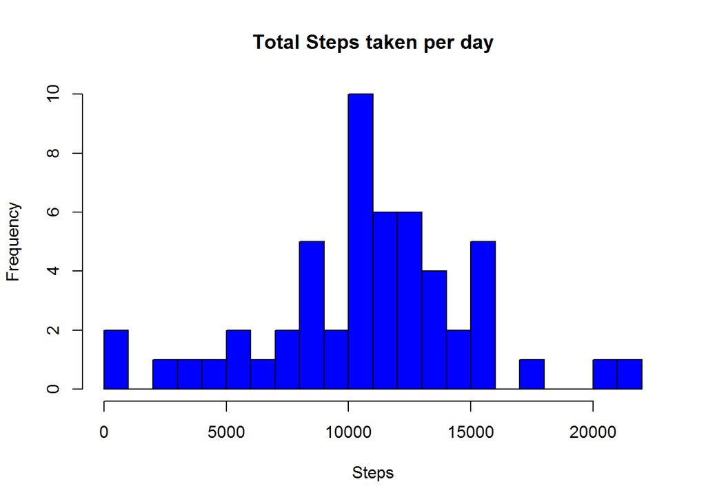

```r
hist(dailysum$steps, breaks = 20, xlab = "Steps", main = "Total Steps taken per day", col = "blue")
```

```r
# mean of number of steps taken per day
mean(dailysum$steps)
```

```
## [1] 10766.19
```

```r
#median of number of steps taken per day
median(dailysum$steps)
```

```
## [1] 10765
```

**Time series plot of the average number of steps taken**

```r
# calculate the average number of steps taken in each time interval in a day
averageSteps <- aggregate(Activity_noNA$steps, list(interval = as.numeric(Activity_noNA$interval)), FUN = "mean")
colnames(averageSteps) <- c("interval", "meanSteps")
head(averageSteps)
```

```
##   interval meanSteps
## 1        0 1.7169811
## 2        5 0.3396226
## 3       10 0.1320755
## 4       15 0.1509434
## 5       20 0.0754717
## 6       25 2.0943396
```

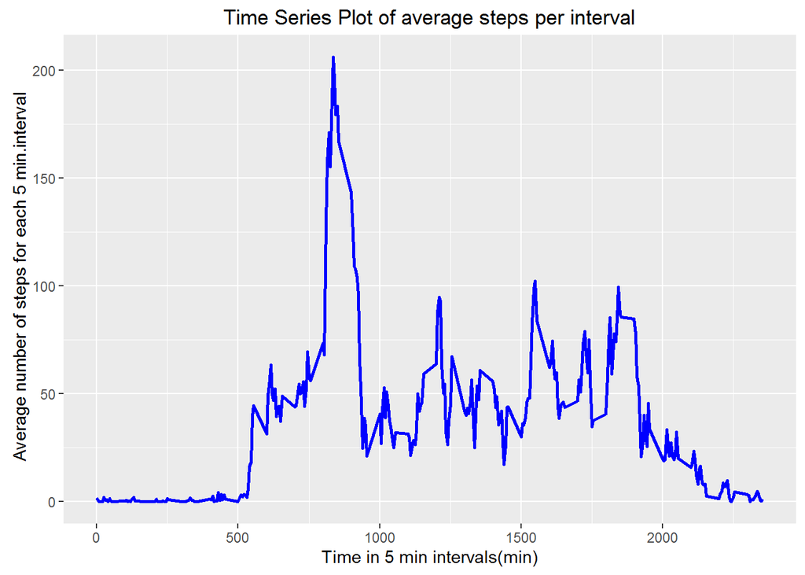

```r
ggplot(averageSteps, aes(interval, meanSteps)) + geom_line(color = "blue", size = 1.0) +
       labs(x = "Time in 5 min intervals(min)", y = " Average number of steps for each 5 min.interval",             title = "Time Series Plot of average steps per interval")
```

** The 5 minute interval that on average contains the maximum number of steps**

```r
MaximumSteps <- max(averageSteps$meanSteps)
averageSteps[averageSteps$meanSteps == MaximumSteps, 1]
```

```
## [1] 835
```

**6. Code to describe and show a strategy for imputing missing data**